# Final Project: Contraception Trends and Factors (Guinea DHS)

Analysis of factors influencing the use of modern contraception in Guinea

Lancinet KEITA

2025-21-09

# Introduction

## About the Demographic and Health Survey (DHS):

The Demographic and Health Surveys (DHS) are a series of standardized surveys conducted periodically in developing countries that collect data on various aspects of population, health, and nutrition.

## About DHS data used for the report:

This final data analysis project will be conducted on the individual recode data set for Guinea. The dataset contains individual-level information on men and women aged 15 to 49 in the surveyed households. This analysis focuses on the women data.

**Year of fieldwork:** 2018

**Full data set for Guinea:** 10,874 women

## About the analyses

This project will investigate factors that may influence or affect a woman’s likelihood to use modern contraception in Guinea.

## Social demographic characteristics

The mean age of women in the data is 28.7, illustrating a relatively young group of women. The mean age of women in rural and urban areas is similar: 26.92 for urban areas and 29.17 in rural areas (table 1).

Table 1: Number, Mean Age, and Percentage of Women (15–49) by Residence

| Residence Type | Number of Women | Mean Age | Percentage (%) |
| --- | --- | --- | --- |
| urban | 4091 | 26.92 | 37.6 |
| rural | 6783 | 29.17 | 62.4 |

*Comment Table 1:* The average age of women is similar between urban (26.92 years) and rural (29.17 years) areas, indicating a relatively homogeneous age structure. This slight difference may reflect different migration or fertility patterns between environments.

Most of the women surveyed reported having no education level

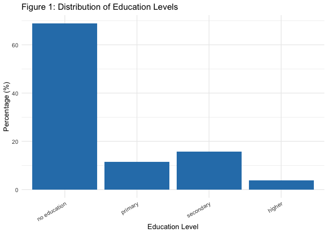

*Comment Figure 1:* The distribution of educational attainment reveals that a large proportion of women have no formal education, potentially limiting access to information on reproductive health.

# Contraception Trends

According to the WHO, modern contraceptive methods include hormonal methods (pills, injectables, implants), intrauterine devices (IUDs), condoms, and sterilization. These methods are highly effective in preventing unintended pregnancies.

By this definition, the modern contraceptive prevalence rate (mCPR) among women in union aged 15-49 in Guinea is relatively low.

## Needs and uses of contraceptive methods

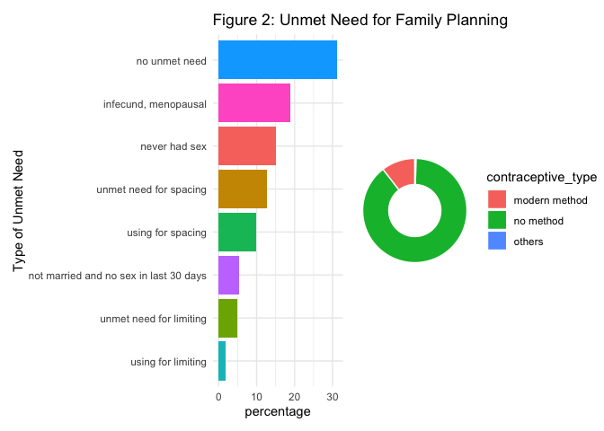

## Place of residence and education

When compared to women in rural areas, women in urban areas are more likely to achieve higher levels of education and use modern contraception.

## Age and contraception

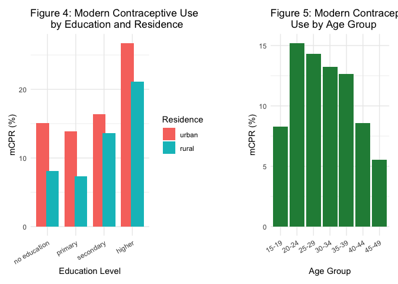

## Wealth and contraception

Women from wealthier households are more likely to use modern contraception, reflecting better access to health services.

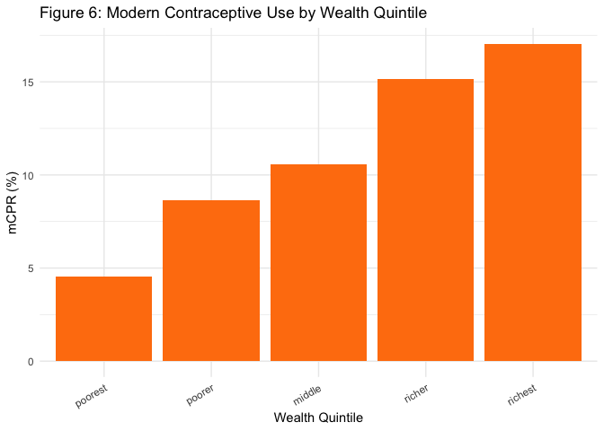

*Comment Figure 6:* The relationship between wealth and contraceptive use shows a marked socio-economic gradient. Women in the wealthiest quintiles use modern contraception significantly more.

## Detailed contraceptive prevalence by region

This figure provides a comprehensive view of modern contraceptive prevalence rates across all regions of Guinea, with confidence intervals to show the precision of estimates.

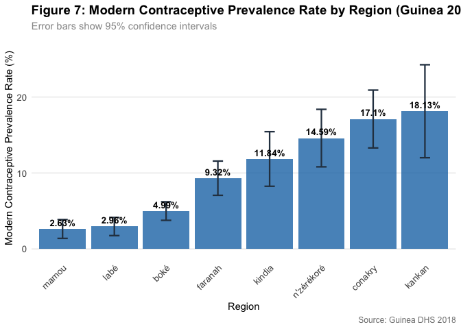

*Comment Figure 7:* This detailed analysis with confidence intervals allows us to precisely identify the regions with the highest and lowest prevalence rates.

## Geographic distribution of contraceptive prevalence

The geographic map shows the spatial distribution of modern contraceptive use across Guinea’s regions with detailed prevalence rates and region labels.

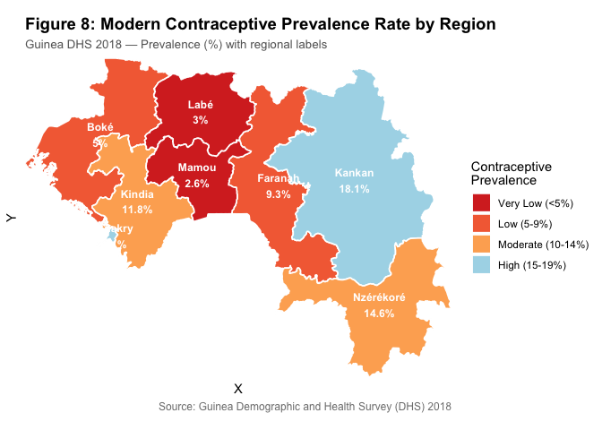

*Comment Figure 8:* The map clearly reveals spatial disparities in access to modern contraception.

# Conclusion

The analysis explored factors influencing women’s use of modern contraception in Guinea. Key patterns emerged:

*Higher likelihood of use* among women in urban areas, with higher education, greater household wealth, and better access to health services.

*Lower likelihood of use* among women in rural areas, with little or no education, lower household wealth, and limited health service access.

Regional disparities were evident, underscoring the need for targeted interventions in areas with low contraceptive prevalence.

## About Guinea

The Republic of Guinea is located in West Africa. It shares borders with Guinea-Bissau, Senegal, Mali, Côte d’Ivoire, Liberia, and Sierra Leone. Guinea has a population of approximately 13 million people and is rich in natural resources, particularly bauxite, iron ore, and gold.

The country faces significant health challenges, including low contraceptive prevalence rates and high maternal and child mortality. Improving access to family planning services remains a priority for the country’s health system.

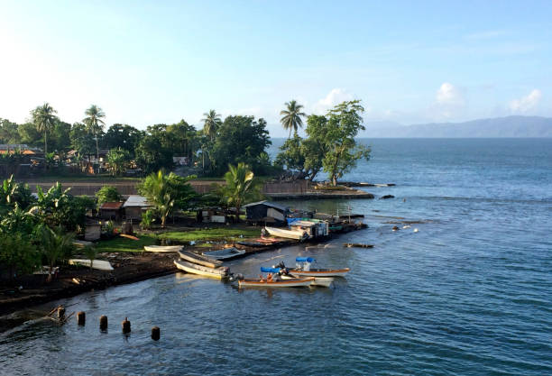

## Labels for variables used in project

**Labels for variables used in project** Survey/Weighting Variables: v005 = sample_weight, v021 = cluster_id, v022 = strata

**Household factors:** v024 = region, v025 = Type of place of residence (urban_rural)

**Characteristics:** v012 = Current age (women), v013 = Age group, v106 = Highest educational level (women), v131 = Ethnicity

**Marital status:** v502 = Currently/formerly/never married

**Finances:** v190 = wealth_index (Indice de richesse combiné)

**Family planning:** v313 = contraceptive_type (Type de méthode contraceptive utilisée), v626a = unmet_need_fp (Besoin non satisfait de planification familiale), v304_01 = approve_fp_respondent (Approbation de la planification familiale par le répondant)

# References

- [Family planning/contraception methods](https://www.who.int/news-room/fact-sheets/detail/family-planning-contraception)
- [DHS Program methodology](https://dhsprogram.com/methodology/)
- [The Graph Courses](https://thegraphcourses.org/)